# Incommensurable bandit model

Keivn J.S. Zollman

March 3, 2019

## Introduction

This is an R Markdown document to develop graphs for the IncommensurableBanditModel. Explanation for the model and how it works can be found elsewhere.

There are two main sections here, one where one bandit dominates the other, thus there is no ambiguity about “good” means in the long run. The second is where one bandit is better on one dimension and the other is worse on that dimension.

## Dominating arm

### What’s the best correlation?

```r
rawCorrelation <- read.csv("../data/IncomEpsilonSearch.csv", header=TRUE)

# The Filtering here is to only select the data where one bandit dominates.  The other part of the data will be looked at below.

domCorrelation <- rawCorrelation %>%
  filter(b1Mean2 == 10) %>%
  group_by(ResultCorrelation) %>%
  summarize(subPerf = mean(subPerformance), subPerfVar = sum(subPerformanceVar * (NumberOfTrials - 1))/(sum(NumberOfTrials) - 1), totalTrials = sum(NumberOfTrials), objPerf = mean(objPerformance1), objPerfVar = sum(objPerformance1Var * (NumberOfTrials - 1))/(sum(NumberOfTrials) - 1), totalTrials = sum(NumberOfTrials)) %>%
  mutate(subCI = qt(.975,df=totalTrials - 1)*(sqrt(subPerfVar)/sqrt(totalTrials)), objCI = qt(.975,df=totalTrials - 1)*(sqrt(objPerfVar)/sqrt(totalTrials)) )
```

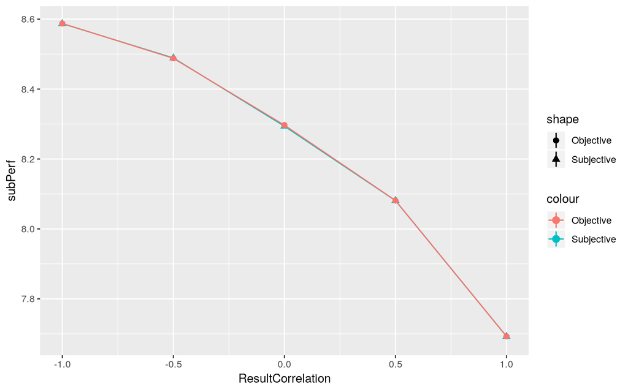

```r
plot <- ggplot(domCorrelation, aes(x = ResultCorrelation)) +
  geom_line(aes(y = subPerf, color = "Subjective")) +
  geom_pointrange(aes(y = subPerf, color = "Subjective", shape = "Subjective", ymin = subPerf - subCI, ymax = subPerf + subCI)) +
  geom_line(aes(y = objPerf, color = "Objective")) +
  geom_pointrange(aes(y = objPerf, color = "Objective", shape = "Objective", ymin = objPerf - objCI, ymax = objPerf + objCI))

plot
```

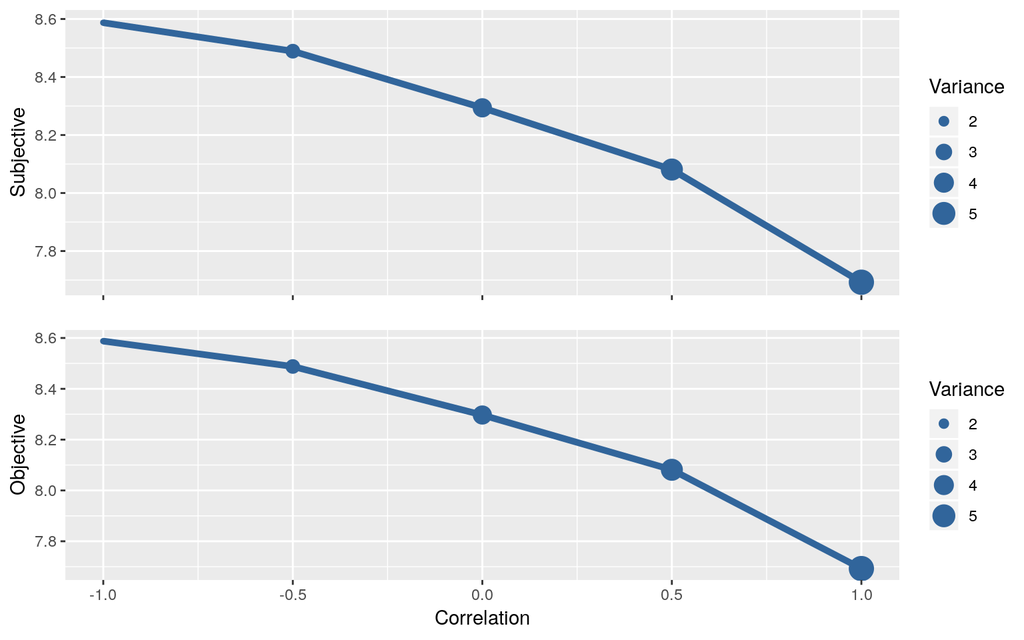

```r
plot <- ggplot(domCorrelation, aes(x = ResultCorrelation))

subplot <- plot + geom_line(aes(y = subPerf), color = DarkBlue, size = 1.75) +
  geom_point(aes(y=subPerf, size = subPerfVar), color = DarkBlue) + theme(axis.text.x = element_blank()) + xlab(element_blank()) + ylab("Subjective") + labs(size = "Variance")

objplot <- plot + geom_line(aes(y = objPerf), color = DarkBlue, size = 1.75) +
  geom_point(aes(y = objPerf, size = objPerfVar), color = DarkBlue) + xlab("Correlation") + ylab("Objective") + labs(size = "Variance")

grid.arrange(subplot, objplot, ncol = 1)
```

### Comparing Epsilon & corrrelations

```r
rawEpsilon <- read.csv("../data/IncomEpsilonSearch.csv", header=TRUE)

# The Filtering here is to only select the data where one bandit dominates.  The other part of the data will be looked at below.

domEpsilon <- rawEpsilon %>%
  filter(b1Mean2 == 10) %>%
  group_by(Epsilon, ResultCorrelation) %>%
  summarize(subPerf = mean(subPerformance), subPerfVar = sum(subPerformanceVar * (NumberOfTrials - 1))/(sum(NumberOfTrials) - 1), totalTrials = sum(NumberOfTrials), objPerf = mean(objPerformance1), objPerfVar = sum(objPerformance1Var * (NumberOfTrials - 1))/(sum(NumberOfTrials) - 1), totalTrials = sum(NumberOfTrials)) %>%
  mutate(subCI = qt(.975,df=totalTrials - 1)*(sqrt(subPerfVar)/sqrt(totalTrials)), objCI = qt(.975,df=totalTrials - 1)*(sqrt(objPerfVar)/sqrt(totalTrials)) )
```

Performance, as measured subjectively

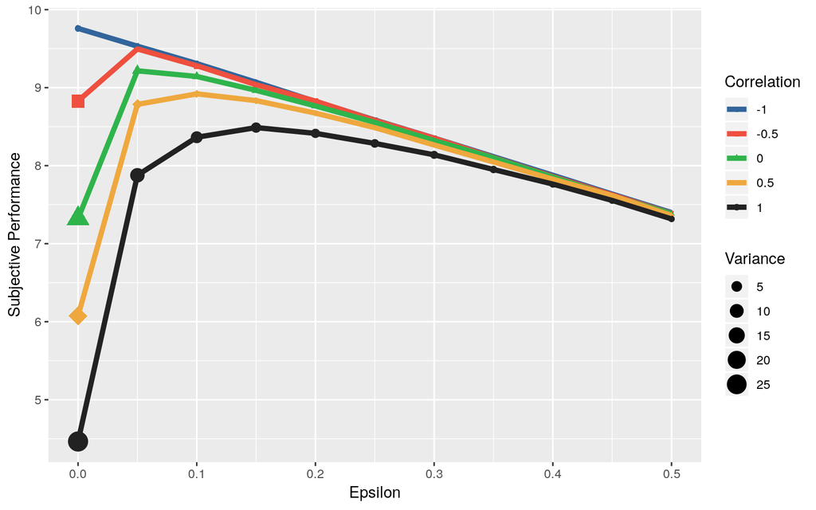

```r
plot <- ggplot(domEpsilon, aes(x = Epsilon, y = subPerf, group = ResultCorrelation, color = as.character(ResultCorrelation), shape = as.character(ResultCorrelation)))

plot + geom_point(aes(size = subPerfVar)) + geom_line(size = 1.75) + scale_color_manual(breaks = c("-1", "-0.5", "0", "0.5", "1"), values=c(DarkRed, DarkBlue, DarkGreen, DarkYellow, "#222222"), name = "Correlation")  + scale_shape_manual(breaks = c("-1", "-0.5", "0", "0.5", "1"), values=c(15, 16, 17, 18, 19), name = "Correlation") + ylab("Subjective Performance") + labs(size = "Variance")
```

Performance, as measured objectively (i.e. dimension 1 is the right dimension)

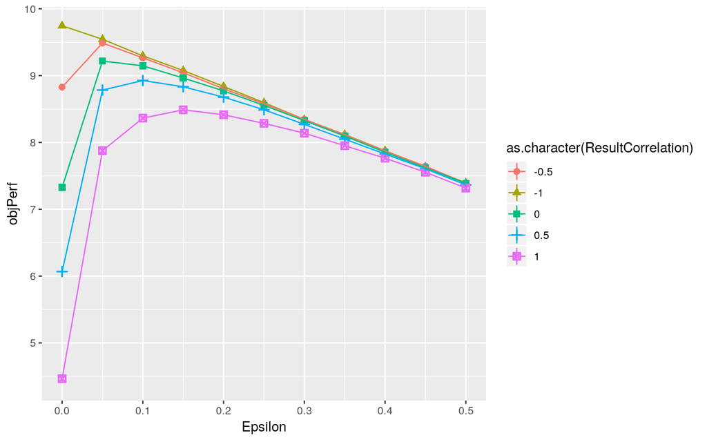

```r
plot <- ggplot(domEpsilon, aes(x = Epsilon, y = objPerf, group = ResultCorrelation, color = as.character(ResultCorrelation), shape = as.character(ResultCorrelation), min = objPerf - objCI, ymax = objPerf + objCI))

plot + geom_pointrange() + geom_line()
```

### Population division

```r
rawPopDivision <- read.csv("../data/IncomPreferenceSearch.csv", header=TRUE)

# The Filtering here is to only select the data where one bandit dominates.  The other part of the data will be looked at below.

domPopDivision <- rawPopDivision %>%
  filter(b1Mean2 == 10) %>%
  group_by(PreferenceBias, ResultCorrelation) %>%
  summarize(subPerf = mean(subPerformance), subPerfVar = sum(subPerformanceVar * (NumberOfTrials - 1))/(sum(NumberOfTrials) - 1), totalTrials = sum(NumberOfTrials), objPerf = mean(objPerformance1), objPerfVar = sum(objPerformance1Var * (NumberOfTrials - 1))/(sum(NumberOfTrials) - 1), totalTrials = sum(NumberOfTrials)) %>%
  mutate(subCI = qt(.975,df=totalTrials - 1)*(sqrt(subPerfVar)/sqrt(totalTrials)), objCI = qt(.975,df=totalTrials - 1)*(sqrt(objPerfVar)/sqrt(totalTrials)) )
```

Performance, as measured subjectively

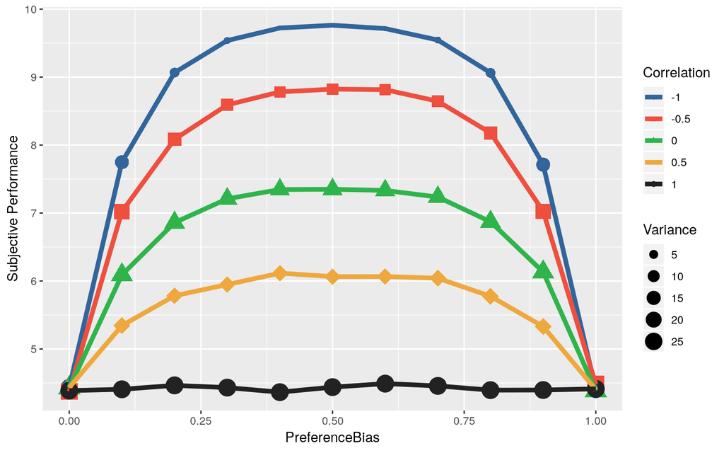

```r
plot <- ggplot(domPopDivision, aes(x = PreferenceBias, y = subPerf, group = ResultCorrelation, color = as.character(ResultCorrelation), shape = as.character(ResultCorrelation)))

plot + geom_point(aes(size = subPerfVar)) + geom_line(size = 1.75) + scale_color_manual(breaks = c("-1", "-0.5", "0", "0.5", "1"), values=c(DarkRed, DarkBlue, DarkGreen, DarkYellow, "#222222"), name = "Correlation")  + scale_shape_manual(breaks = c("-1", "-0.5", "0", "0.5", "1"), values=c(15, 16, 17, 18, 19), name = "Correlation") + ylab("Subjective Performance") + labs(size = "Variance")
```

Performance, as measured objectively (i.e. dimension 1 is the right dimension)

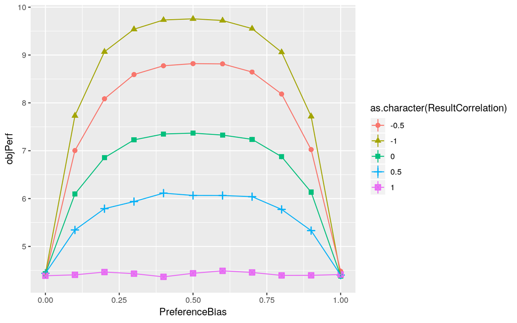

```r
plot <- ggplot(domPopDivision, aes(x = PreferenceBias, y = objPerf, group = ResultCorrelation, color = as.character(ResultCorrelation), shape = as.character(ResultCorrelation), min = objPerf - objCI, ymax = objPerf + objCI))

plot + geom_pointrange() + geom_line()
```

### Variance comparisons

```r
rawVarComp <- read.csv("../data/IncomDoubleVarianceSearch.csv", header=TRUE)


domVarianceComp <- rawVarComp %>%
  filter(b1Mean2 == 10) %>%
  group_by(b1Variance, b2Variance) %>%
  summarize(subPerf = mean(subPerformance),
            subPerfVar = sum(subPerformanceVar * (NumberOfTrials - 1))/(sum(NumberOfTrials) - 1),
            totalTrials = sum(NumberOfTrials),
            objPerf = mean(objPerformance1),
            objPerfVar = sum(objPerformance1Var * (NumberOfTrials - 1))/(sum(NumberOfTrials) - 1),
            totalTrials = sum(NumberOfTrials))
```

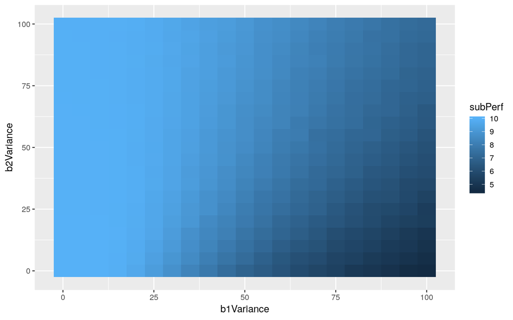

```r
ggplot(domVarianceComp, aes(x = b1Variance, y = b2Variance, fill = subPerf)) + geom_tile()
```

## Non-dominance

### What’s the best correlation

```r
nonDomCorrelation <- rawCorrelation %>%
  filter(b1Mean2 == -10) %>%
  group_by(ResultCorrelation) %>%
  summarize(subPerf = mean(subPerformance), subPerfVar = sum(subPerformanceVar * (NumberOfTrials - 1))/(sum(NumberOfTrials) - 1), totalTrials = sum(NumberOfTrials), objPerf1 = mean(objPerformance1), objPerfVar1 = sum(objPerformance1Var * (NumberOfTrials - 1))/(sum(NumberOfTrials) - 1), totalTrials = sum(NumberOfTrials), objPerf2 = mean(objPerformance2), objPerfVar2 = sum(objPerformance2Var * (NumberOfTrials - 1))/(sum(NumberOfTrials) - 1), totalTrials = sum(NumberOfTrials)) %>%
  mutate(subCI = qt(.975,df=totalTrials - 1)*(sqrt(subPerfVar)/sqrt(totalTrials)), objCI1 = qt(.975,df=totalTrials - 1)*(sqrt(objPerfVar1)/sqrt(totalTrials)), objCI2 = qt(.975,df=totalTrials - 1)*(sqrt(objPerfVar2)/sqrt(totalTrials)) )
```

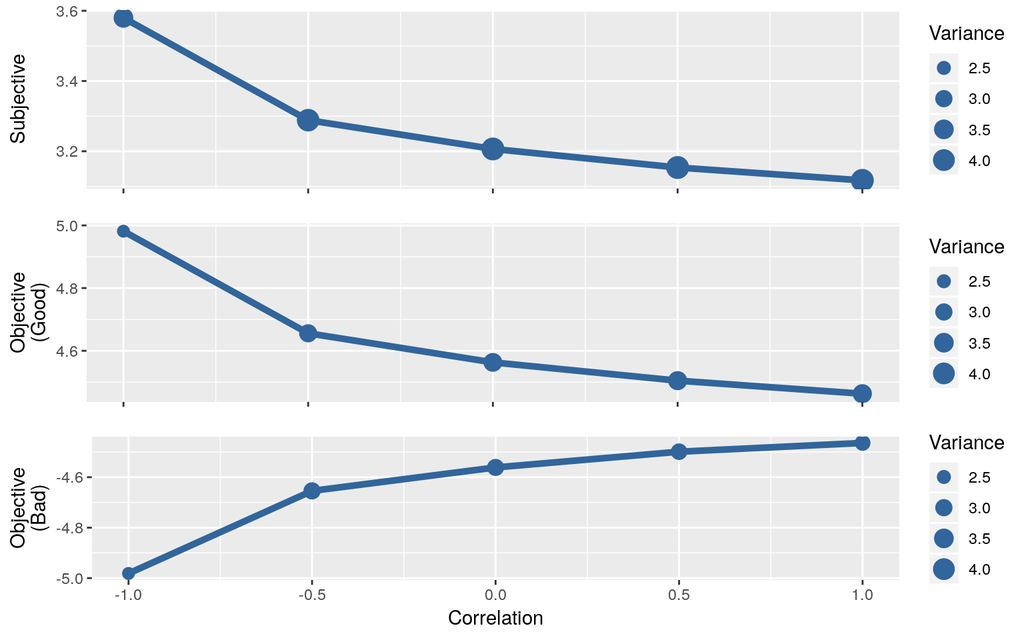

```r
plot <- ggplot(nonDomCorrelation, aes(x = ResultCorrelation))

subPlot <- plot +
  geom_line(aes(y = subPerf), color = DarkBlue, size = 1.75) +
  geom_point(aes(y = subPerf, size = subPerfVar, label = subPerfVar), color = DarkBlue) +
  theme(axis.text.x = element_blank()) + xlab(element_blank()) + ylab("Subjective\n") + labs(size = "Variance") + scale_y_continuous(breaks = c(3.0, 3.2, 3.4, 3.6, 3.8)) + scale_size(breaks = c(2.5, 3, 3.5, 4), limits = c(2.0, 5.0))
obj1Plot <- plot +
  geom_line(aes(y = objPerf1), color = DarkBlue, size = 1.75) +
  geom_point(aes(y = objPerf1, size = objPerfVar1), color = DarkBlue)  + theme(axis.text.x = element_blank()) + xlab(element_blank()) + ylab("Objective\n(Good)") + labs(size = "Variance") + scale_size(breaks = c(2.5, 3, 3.5, 4), limits = c(2.0, 5.0))

obj2Plot <- plot +
  geom_line(aes(y = objPerf2), color = DarkBlue, size = 1.75) +
  geom_point(aes(y = objPerf2, size = objPerfVar2), color = DarkBlue) + xlab("Correlation") + ylab("Objective\n(Bad)") + labs(size = "Variance") + scale_size(breaks = c(2.5, 3, 3.5, 4), limits = c(2.0, 5.0))

grid.arrange(subPlot, obj1Plot, obj2Plot, ncol = 1)
```

### Epsilon

In this section, things are a little more complicated. Now suppose that one bandit arm is better on one dimension than the other one.

```r
nonDomEpsilon <- rawEpsilon %>%
  filter(b1Mean2 == -10) %>%
  group_by(Epsilon, ResultCorrelation) %>%
  summarize(subPerf = mean(subPerformance), subPerfVar = sum(subPerformanceVar * (NumberOfTrials - 1))/(sum(NumberOfTrials) - 1), totalTrials = sum(NumberOfTrials), objPerf1 = mean(objPerformance1), objPerfVar1 = sum(objPerformance1Var * (NumberOfTrials - 1))/(sum(NumberOfTrials) - 1), totalTrials = sum(NumberOfTrials), objPerf2 = mean(objPerformance2), objPerfVar2 = sum(objPerformance2Var * (NumberOfTrials - 1))/(sum(NumberOfTrials) - 1), totalTrials = sum(NumberOfTrials)) %>%
  mutate(subCI = qt(.975,df=totalTrials - 1)*(sqrt(subPerfVar)/sqrt(totalTrials)), objCI1 = qt(.975,df=totalTrials - 1)*(sqrt(objPerfVar1)/sqrt(totalTrials)), objCI2 = qt(.975,df=totalTrials - 1)*(sqrt(objPerfVar2)/sqrt(totalTrials)) )
```

Performance, as measured subjectively

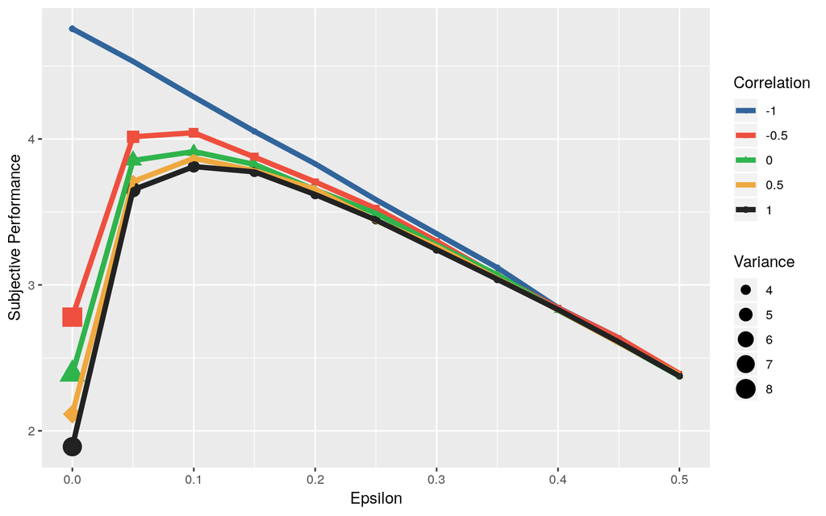

```r
plot <- ggplot(nonDomEpsilon, aes(x = Epsilon, y = subPerf, group = ResultCorrelation, color = as.character(ResultCorrelation), shape = as.character(ResultCorrelation)))

plot + geom_point(aes(size = subPerfVar)) + geom_line(size = 1.75) + scale_color_manual(breaks = c("-1", "-0.5", "0", "0.5", "1"), values=c(DarkRed, DarkBlue, DarkGreen, DarkYellow, "#222222"), name = "Correlation")  + scale_shape_manual(breaks = c("-1", "-0.5", "0", "0.5", "1"), values=c(15, 16, 17, 18, 19), name = "Correlation") + ylab("Subjective Performance") + labs(size = "Variance")
```

Performance, as measured objectively (i.e. dimension 1 is the right dimension) assuming that the bandit with the larger variance is better.

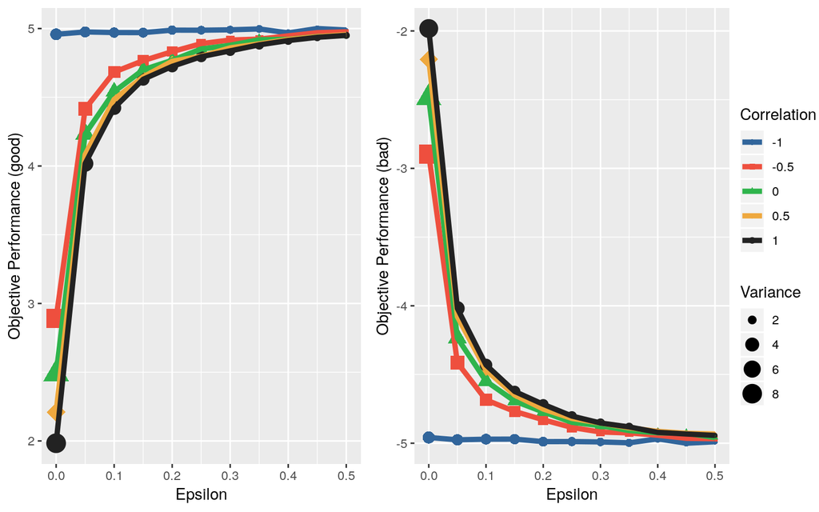

```r
plot <- ggplot(nonDomEpsilon, aes(x = Epsilon, y = objPerf1, group = ResultCorrelation, color = as.character(ResultCorrelation), shape = as.character(ResultCorrelation)))

objplot1 = plot + geom_point(aes(size = objPerfVar1)) + geom_line(size = 1.75) + scale_color_manual(breaks = c("-1", "-0.5", "0", "0.5", "1"), values=c(DarkRed, DarkBlue, DarkGreen, DarkYellow, "#222222"), name = "Correlation")  + scale_shape_manual(breaks = c("-1", "-0.5", "0", "0.5", "1"), values=c(15, 16, 17, 18, 19), name = "Correlation") + ylab("Objective Performance (good)") + labs(size = "Variance")

plot <- ggplot(nonDomEpsilon, aes(x = Epsilon, y = objPerf2, group = ResultCorrelation, color = as.character(ResultCorrelation), shape = as.character(ResultCorrelation)))

objplot2 = plot + geom_point(aes(size = objPerfVar2)) + geom_line(size = 1.75) + scale_color_manual(breaks = c("-1", "-0.5", "0", "0.5", "1"), values=c(DarkRed, DarkBlue, DarkGreen, DarkYellow, "#222222"), name = "Correlation")  + scale_shape_manual(breaks = c("-1", "-0.5", "0", "0.5", "1"), values=c(15, 16, 17, 18, 19), name = "Correlation") + ylab("Objective Performance (bad)") + labs(size = "Variance")

legend = gtable_filter(ggplot_gtable(ggplot_build(objplot1)), "guide-box")

grid.arrange(objplot1 + theme(legend.position="none"), objplot2 + theme(legend.position="none"), legend, ncol = 3, widths = c(.45, .45, .1))
```

Performance, as measured objectively (i.e. dimension 2 is the right dimension) assuming that the bandit with the larger variance is worse.

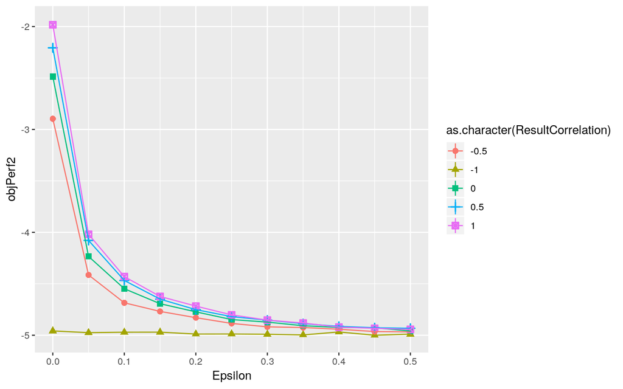

```r
plot <- ggplot(nonDomEpsilon, aes(x = Epsilon, y = objPerf2, group = ResultCorrelation, color = as.character(ResultCorrelation), shape = as.character(ResultCorrelation), min = objPerf2 - objCI2, ymax = objPerf2 + objCI2))

plot + geom_pointrange() + geom_line()
```

### Population division

```r
nonDomPopDivision <- rawPopDivision %>%
  filter(b1Mean2 == -10) %>%
  group_by(PreferenceBias, ResultCorrelation) %>%
  summarize(subPerf = mean(subPerformance),
            subPerfVar = sum(subPerformanceVar * (NumberOfTrials - 1))/(sum(NumberOfTrials) - 1),
            totalTrials = sum(NumberOfTrials), objPerf1 = mean(objPerformance1),
            objPerfVar1 = sum(objPerformance1Var * (NumberOfTrials - 1))/(sum(NumberOfTrials) - 1),
            totalTrials = sum(NumberOfTrials), objPerf2 = mean(objPerformance2),
            objPerfVar2 = sum(objPerformance2Var * (NumberOfTrials - 1))/(sum(NumberOfTrials) - 1),
            totalTrials = sum(NumberOfTrials)) %>%

    mutate(subCI = qt(.975,df=totalTrials - 1)*(sqrt(subPerfVar)/sqrt(totalTrials)),
           objCI1 = qt(.975,df=totalTrials - 1)*(sqrt(objPerfVar1)/sqrt(totalTrials)),
           objCI2 = qt(.975,df=totalTrials - 1)*(sqrt(objPerfVar2)/sqrt(totalTrials)),
           oppPrefBias = 1 - PreferenceBias)
```

Performance, as measured subjectively

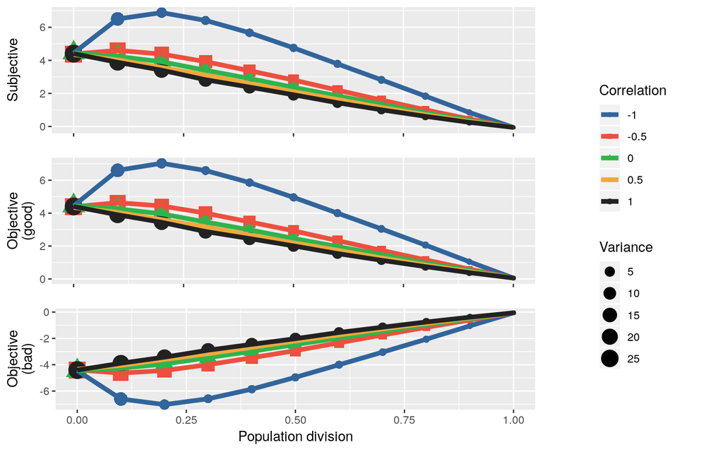

```r
plot <- ggplot(nonDomPopDivision, aes(x = oppPrefBias, y = subPerf, group = ResultCorrelation, color = as.character(ResultCorrelation), shape = as.character(ResultCorrelation)))

subplot = plot + geom_point(aes(size = subPerfVar)) + geom_line(size = 1.75) + scale_color_manual(breaks = c("-1", "-0.5", "0", "0.5", "1"), values=c(DarkRed, DarkBlue, DarkGreen, DarkYellow, "#222222"), name = "Correlation")  + scale_shape_manual(breaks = c("-1", "-0.5", "0", "0.5", "1"), values=c(15, 16, 17, 18, 19), name = "Correlation") + ylab("Subjective\n") + labs(size = "Variance") + xlab(element_blank()) + theme(axis.text.x = element_blank())

plot <- ggplot(nonDomPopDivision, aes(x = oppPrefBias, y = objPerf1, group = ResultCorrelation, color = as.character(ResultCorrelation), shape = as.character(ResultCorrelation)))

objplot1 =  plot + geom_point(aes(size = objPerfVar1)) + geom_line(size = 1.75) + scale_color_manual(breaks = c("-1", "-0.5", "0", "0.5", "1"), values=c(DarkRed, DarkBlue, DarkGreen, DarkYellow, "#222222"), name = "Correlation")  + scale_shape_manual(breaks = c("-1", "-0.5", "0", "0.5", "1"), values=c(15, 16, 17, 18, 19), name = "Correlation") + ylab("Objective\n(good)") + labs(size = "Variance") + xlab(element_blank()) + theme(axis.text.x = element_blank())

plot <- ggplot(nonDomPopDivision, aes(x = oppPrefBias, y = objPerf2, group = ResultCorrelation, color = as.character(ResultCorrelation), shape = as.character(ResultCorrelation), min = objPerf2 - objCI2, ymax = objPerf2 + objCI2))

objplot2 = plot + geom_point(aes(size = objPerfVar1)) + geom_line(size = 1.75) + scale_color_manual(breaks = c("-1", "-0.5", "0", "0.5", "1"), values=c(DarkRed, DarkBlue, DarkGreen, DarkYellow, "#222222"), name = "Correlation")  + scale_shape_manual(breaks = c("-1", "-0.5", "0", "0.5", "1"), values=c(15, 16, 17, 18, 19), name = "Correlation") + ylab("Objective\n(bad)") + labs(size = "Variance") + xlab("Population division")

legend = gtable_filter(ggplot_gtable(ggplot_build(subplot)), "guide-box")

grid.arrange(arrangeGrob(subplot  + theme(legend.position="none"), objplot1 + theme(legend.position="none"), objplot2 + theme(legend.position="none"), ncol = 1), legend, ncol = 2, widths = c(.75, .25))
```

Performance, as measured objectively (i.e. dimension 2 is the right dimension)

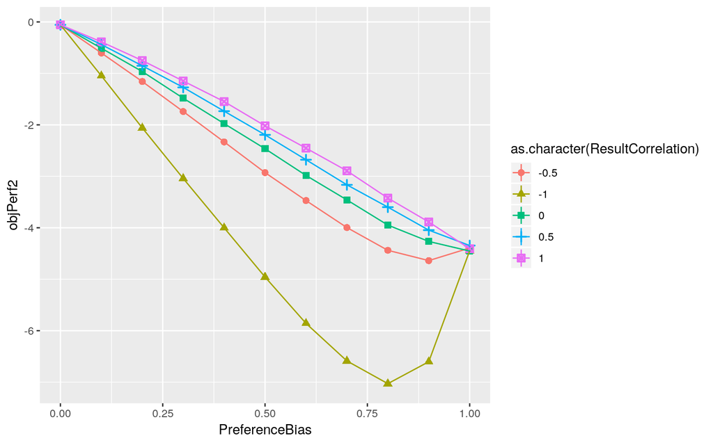

```r
plot <- ggplot(nonDomPopDivision, aes(x = PreferenceBias, y = objPerf2, group = ResultCorrelation, color = as.character(ResultCorrelation), shape = as.character(ResultCorrelation), min = objPerf2 - objCI2, ymax = objPerf2 + objCI2))

plot + geom_pointrange() + geom_line()
```

### Variance comparisons

```r
rawVarComp <- read.csv("../data/IncomDoubleVarianceSearch.csv", header=TRUE)


nonDomVarianceComp <- rawVarComp %>%
  filter(b1Mean2 == -10) %>%
  group_by(b1Variance, b2Variance) %>%
  summarize(subPerf = mean(subPerformance),
            subPerfVar = sum(subPerformanceVar * (NumberOfTrials - 1))/(sum(NumberOfTrials) - 1),
            totalTrials = sum(NumberOfTrials),
            objPerf1 = mean(objPerformance1),
            objPerfVar1 = sum(objPerformance1Var * (NumberOfTrials - 1))/(sum(NumberOfTrials) - 1),
            objPerf2 = mean(objPerformance2),
            objPerfVar2 = sum(objPerformance2Var * (NumberOfTrials - 1))/(sum(NumberOfTrials) - 1))
```

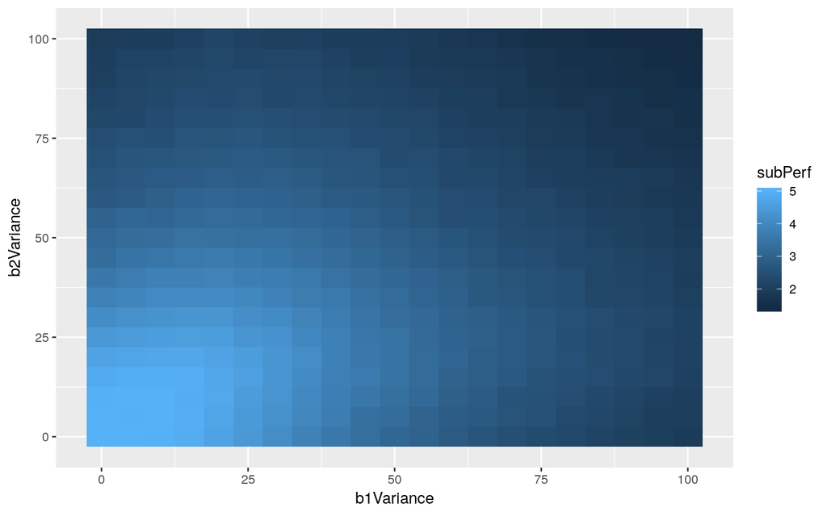

```r
ggplot(nonDomVarianceComp, aes(x = b1Variance, y = b2Variance, fill = subPerf)) + geom_tile()
```

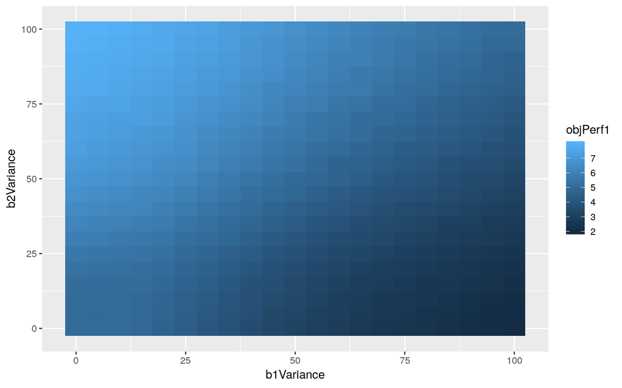

```r
ggplot(nonDomVarianceComp, aes(x = b1Variance, y = b2Variance, fill = objPerf1)) + geom_tile()
```

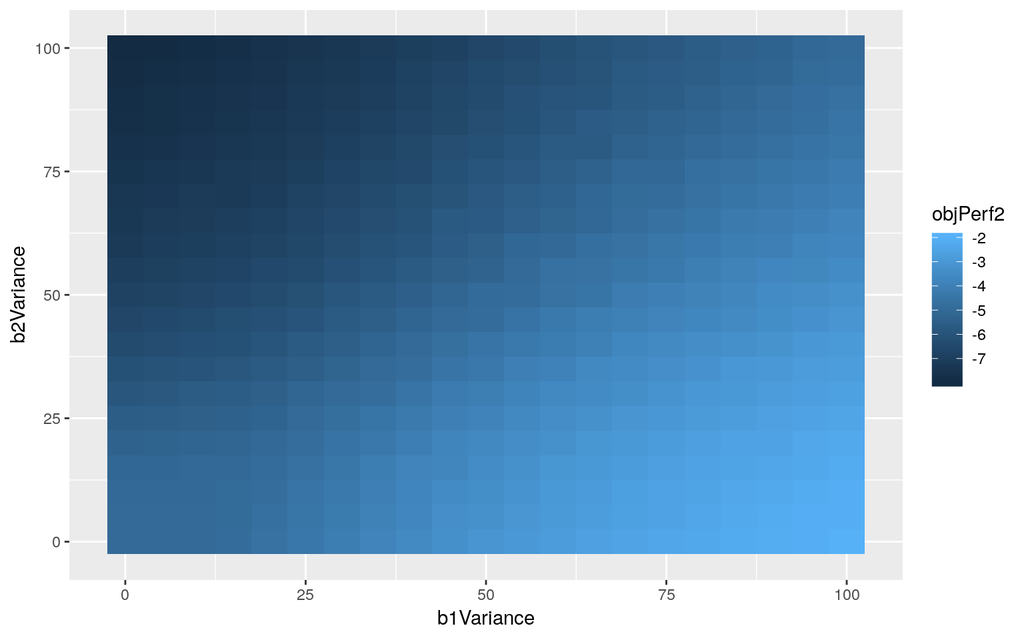

```r
ggplot(nonDomVarianceComp, aes(x = b1Variance, y = b2Variance, fill = objPerf2)) + geom_tile()
```